# Eduardo Demetrio

Controle estatistisco de qualidade

2025-06-02

# Repositório.

- Teremos também um repositório com todas listas no GitHub. 🔗 Repositório no GitHub

## Questão 1

*Um gráfico x é estabelecido com base nos parâmetros µ = 600 e σ = 12, com n = 9, baseado num risco do erro do tipo I (α = 0.01). Quais são os limites de controle?

```
## [1] 589.6967
```

```
## [1] 610.3033
```

## Questão 2

Gráficos de controle 3-sigma X e S são aplicados para monitorar o controle estatístico de um processo. O tamanho amostral é n = 6. Os limites dos gráficos de controle são os seguintes:

```
## [1] 706
```

```
## [1] 1.854988
```

```
## [1] 0.1058218
```

```
## [1] 0.0565421
```

## Questão 3

Amostras de tamanho n = 5 são extraídas de um processo de manufatura a cada hora. Uma característica da qualidade é medida e x e R são calculados a cada amostra. Após a seleção de 25 amostras, foram obtidos: a) Determine os limites de controle para os gráficos x e R; Resposta: (LIC = 26.293, LSC = 26.707 para o gráfico x; LIC = 0, LSC = 0.7611 para o gráfico R). b) Assuma que ambos os gráficos exibam controle. Se as especificações são 26.40 ± 0.50, estime a probabilidade de produção fora das especificações; Resposta: PPFE = 0.0047; c) Se a média do processo fosse 26.40, qual seria a probabilidade de produção fora das especificações? Resposta: PPFE = 0.0012.

```
## [1] 26.5
```

```
## [1] 0.36
```

```
## [1] 26.29228
```

```
## [1] 26.5
```

```
## [1] 26.70772
```

```
## [1] 0
```

```
## [1] 0.36
```

```
## [1] 0.76104
```

```
## [1] 0.004929749
```

```
## [1] 0.001235499
```

## Questão 4

Os dados aprsentados na sequência referem-se aos desvios das espessuras de moldes metálicos em relação à espessura nominal (determinada no projeto), verificados em 30 amostras de tamanho n = 6. As primeiras m = 20 amostras compõem a fase 1 do controle do processo, utilizadas na estimação dos parâmetros e determinação dos limites dos gráficos de controle. As demais amostras foram selecionadas para fins de monitoramento, compondo a segunda fase.

1. Forneça estimativas não viciadas para a média e o desvio padrão do processo (baseadas nas amplitudes e nos desvios padrões amostrais);
2. Determine os limites de controle e de alerta para os gráficos x e R; o mesmo para o par de gráficos x e S;
3. Escolha um par de gráficos, a seu critério. Esboce o par de gráficos usando os resultados da primeira fase. Há algum indicativo de descontrole?
4. Adicione aos gráficos do item anterior os resultados das dez amostras da segunda fase. Há algum indicativo de descontrole? Verifique a ocorrência de alguma das regras sensibilizantes.
5. O gerente da empresa solicitou a você um relatório da análise, descrevendo, brevemente, a metodologia utilizada, a construção dos gráficos, os principais resultados e suas recomendações. Providencie o relatório.

```
## [1] -0.00264
```

```
## [1] 0.05378848
```

```
## [1] 0.05436883
```

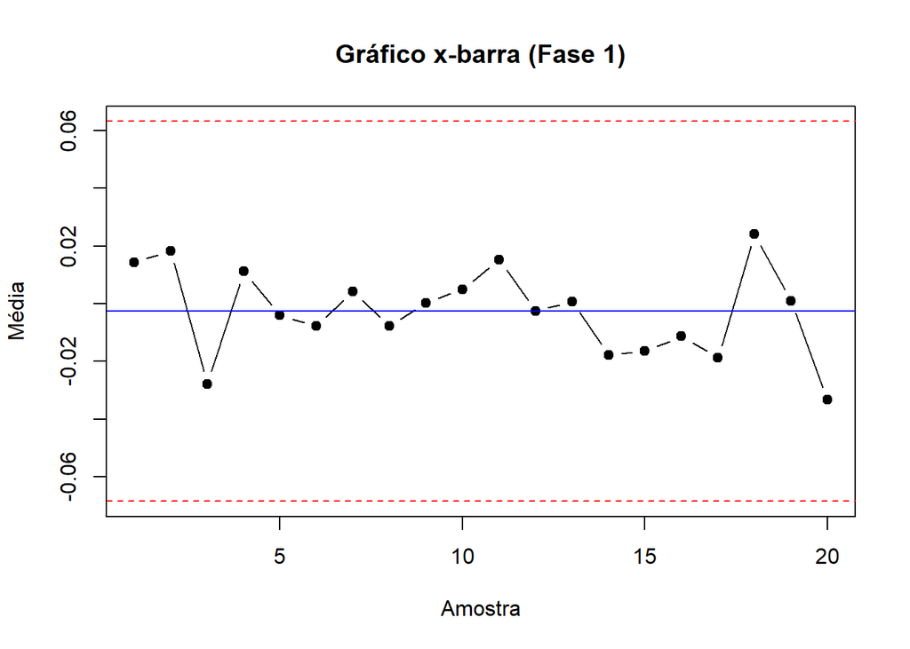

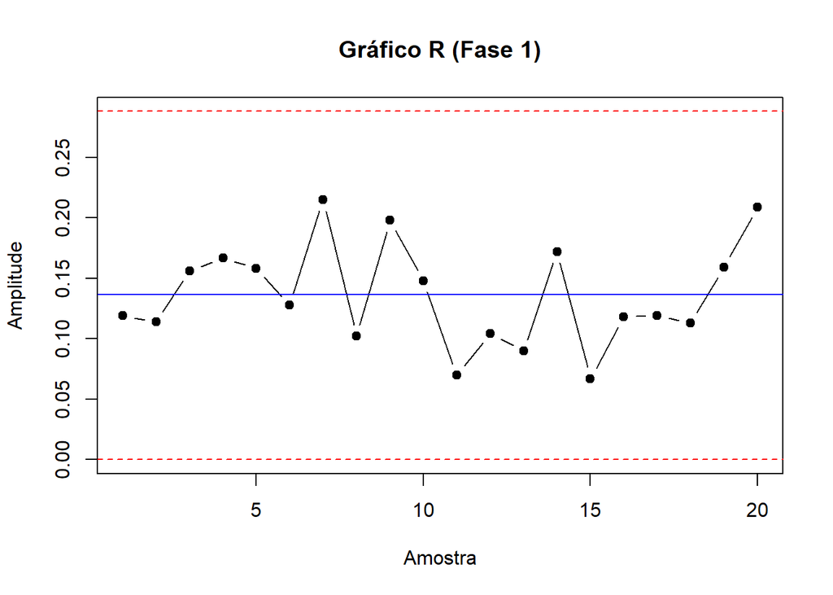

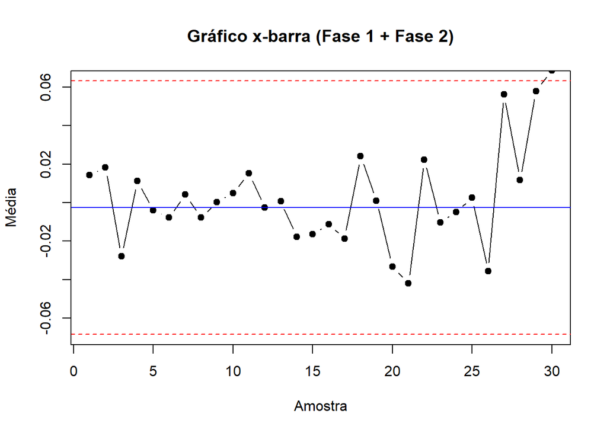

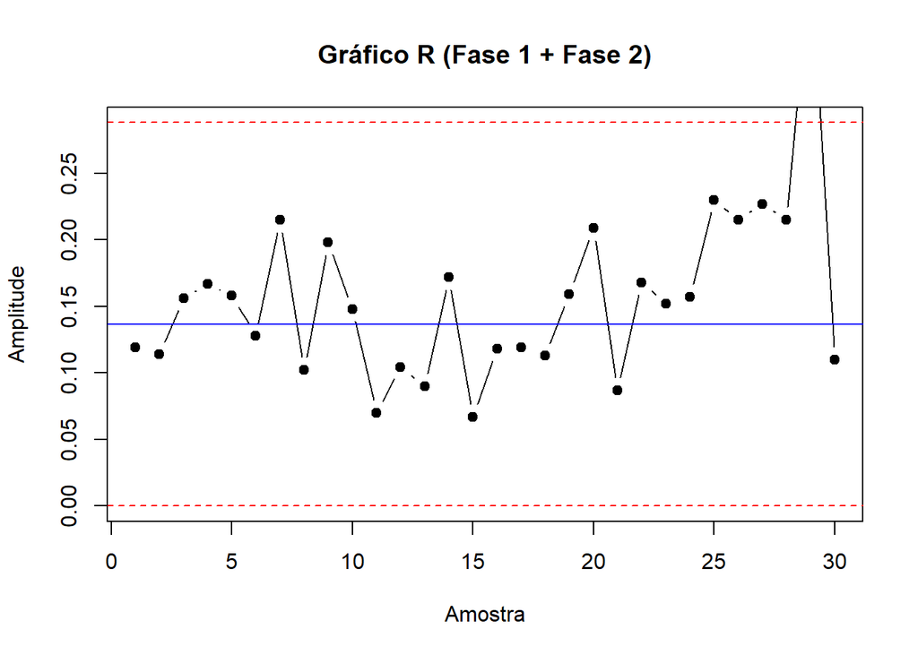

```
## **Relatório Final**
```

```
## Foram utilizados dados de 30 amostras, sendo 20 na Fase 1 e 10 na Fase 2.
```

```
## Os gráficos de controle x-barra e R foram construídos com base nas estimativas:
```

```
## - Média do processo estimada: -0.0026
```

```
## - Desvio padrão estimado por R: 0.0538
```

```
## Os limites de controle foram calculados utilizando as constantes apropriadas de Montgomery (2016).
```

```
## A análise gráfica da Fase 1 mostra um processo aparentemente sob controle.
```

```
## Na Fase 2, foram identificados possíveis indícios de descontrole em algumas amostras, especialmente pela amplitude elevada na amostra 29.
```

```
## Recomenda-se investigar as causas especiais associadas às amostras fora dos limites e aplicar ações corretivas conforme necessário.
```

## Questão 5

```
## Package 'qcc' version 2.7
```

|  | Amostra | Espessura |
| --- | --- | --- |
| 1 | 1 | 459 |
| 2 | 1 | 449 |
| 3 | 1 | 435 |
| 4 | 1 | 450 |
| 5 | 2 | 443 |
| 6 | 2 | 440 |

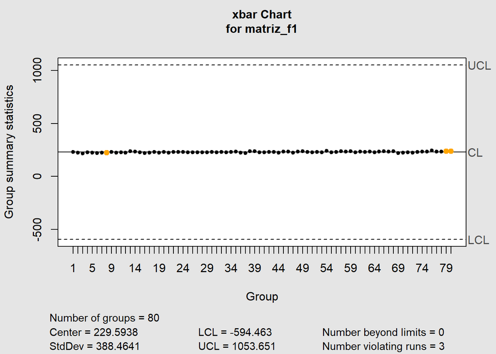

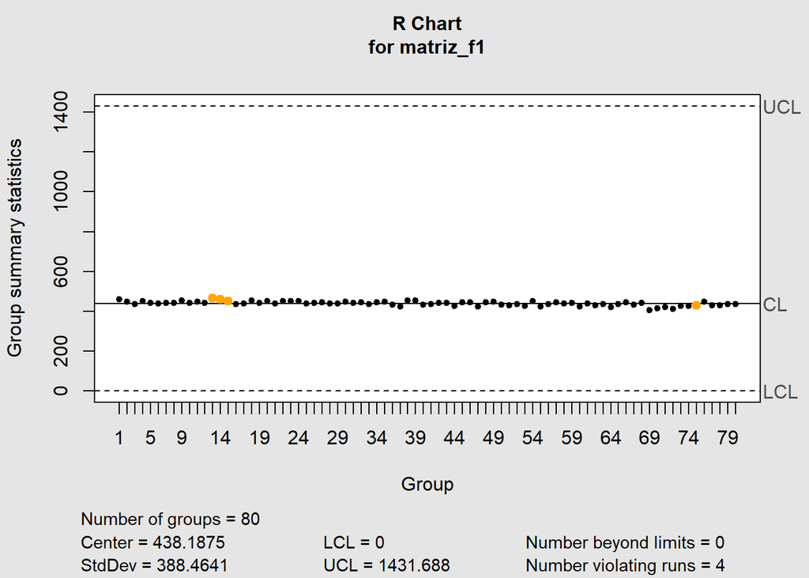

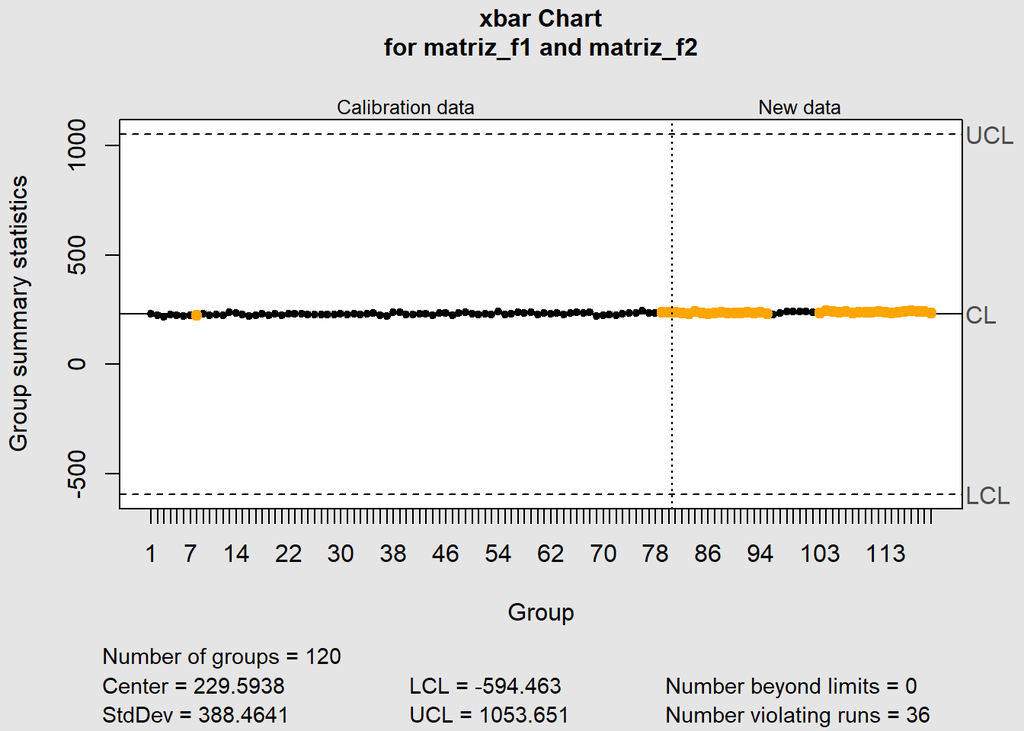

```
## [1] 0.9341294
```

```
## **Conclusão:**
```

[output not shown]

```
## A construção dos gráficos de controle indica se há indícios de descontrole durante a Fase 2.
```

```
## A probabilidade estimada de produção fora das especificações (PPFE) é de aproximadamente 93.41%.
```

## Questão 6

|  | Amostra | Forca |
| --- | --- | --- |
| 1 | 1 | 83.0 |
| 2 | 1 | 81.2 |
| 3 | 1 | 78.7 |
| 4 | 1 | 75.7 |
| 5 | 1 | 77.0 |
| 6 | 2 | 88.6 |

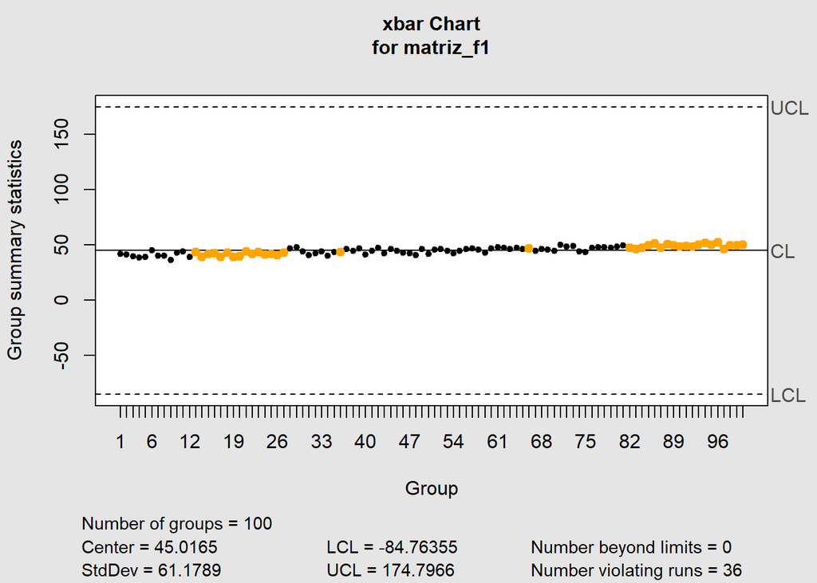

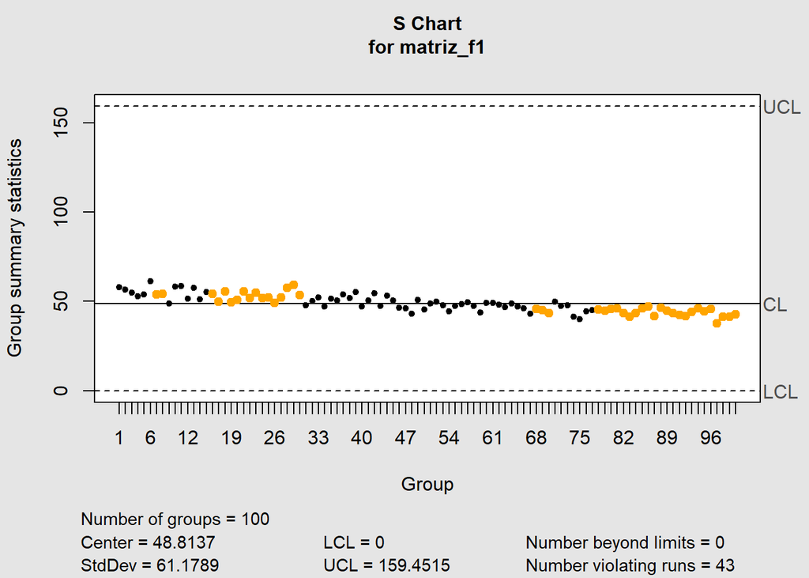

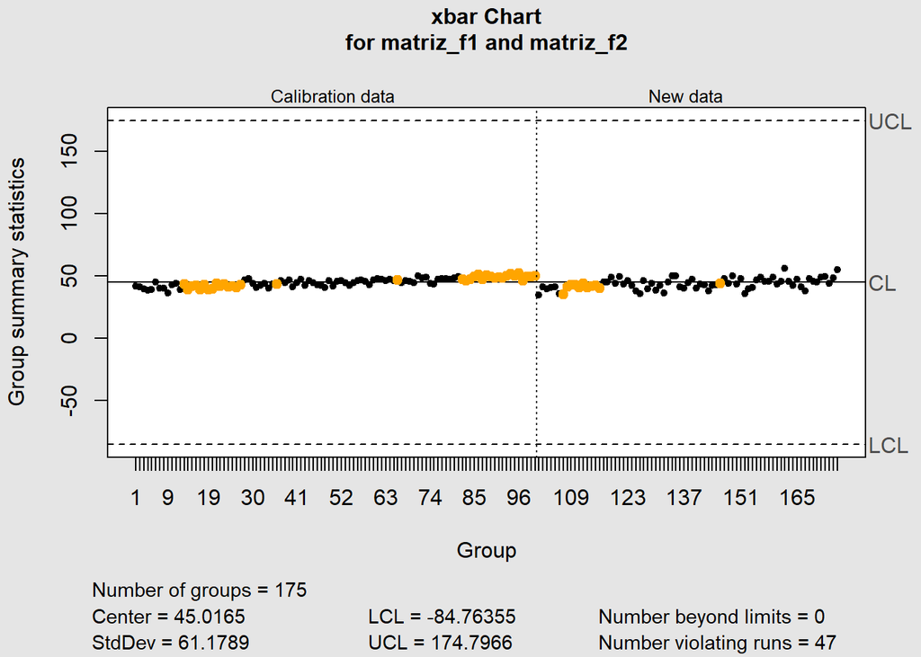

```
## **Conclusão:**
```

[output not shown]

```
## A avaliação dos gráficos mostra se o processo estava sob controle inicialmente.
```

[output not shown]

```
## Se sim, isso indica uma possível causa especial e necessidade de investigação do processo.
```

## Questão 7

A uniformidade de uma pastilha de silício após reação química é determinada pela medição da espessura em várias posições, expressando a uniformidade como a amplitude das espessuras. Parte 1- Dispõe-se das medidas individuais de uniformidade para uma sequência de 30 pastilhas produzidas. Parte 2- Tem-se também os dados adicionais sobre 10 pastilhas produzidas. Com base nesses resultados, o processo parece estar sobre controle? Parte 3- Suponha que a causa atribuível responsável pelo sinal de descontrole tenha sido identificada e eliminada do processo. O monitoramento do processo teve sequência com a seleção de outras 20 amostras unitárias. Usando os limites de controle estabelecidos na primeira parte do exercício. Quais as suas conclusões? Bases past.csv, past2.csv e past3.csv disponíveis na página da disciplina.

[figure not shown]

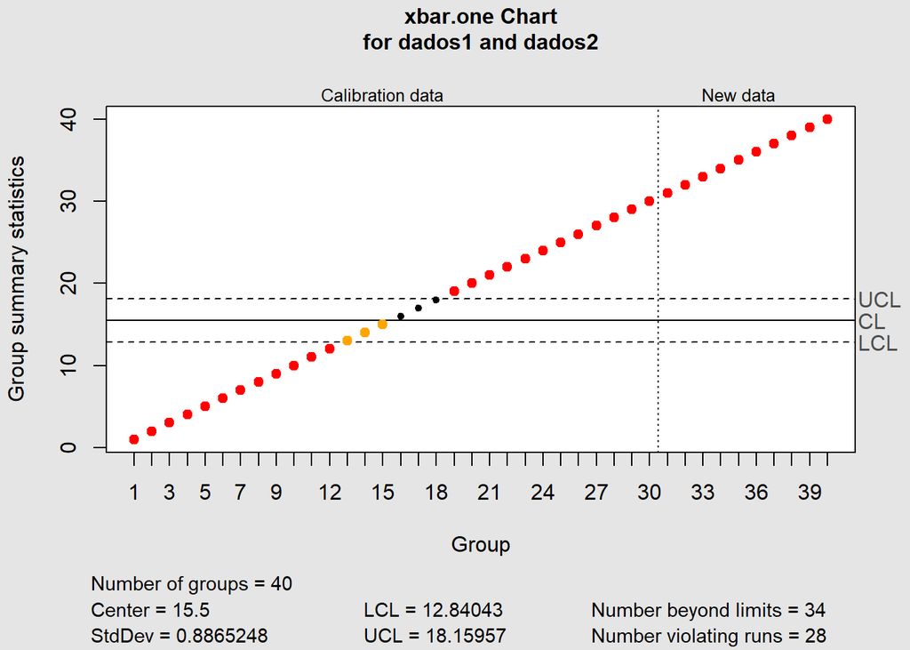

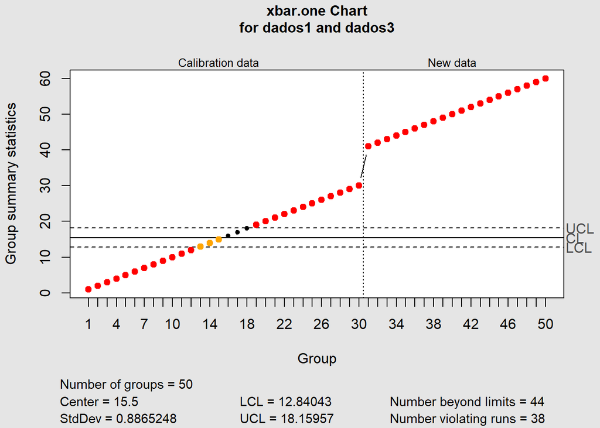

```
## **Conclusões da Questão 7:**
```

```
## **Parte 1:** Os gráficos individuais mostraram os limites de controle com base nas 30 primeiras pastilhas.
```

```
## **Parte 2:** Foram avaliadas 10 novas pastilhas. Caso alguma delas tenha ultrapassado os limites, há indício de descontrole.
```

```
## **Parte 3:** Após a remoção da causa especial, o processo foi monitorado com 20 novas pastilhas.
```

```
## Se todas estiverem dentro dos limites e sem padrão sistemático, o processo está sob controle.
```

## Questão 8

Considere a construção de gráficos de controle para a resistência à tração de cabos de aço. A fase 1 foi planejada para m = 15 amostras de tamanho n = 6. No entanto, em cinco delas apenas n = 5 cabos estavam disponíveis. Para a segunda fase, tendo em vista a dificuldade em atender o tamanho amostral inicialmente planejado, optou-se por fixar n = 4. A variável analisada foi a carga de ruptura (em kg/mm2). As últimas 10 amostras correspondem à fase 2.

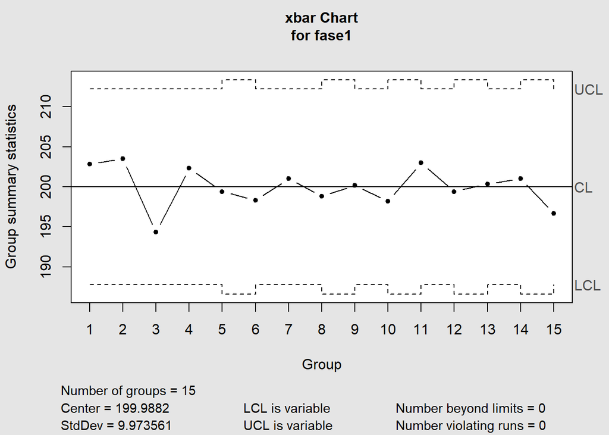

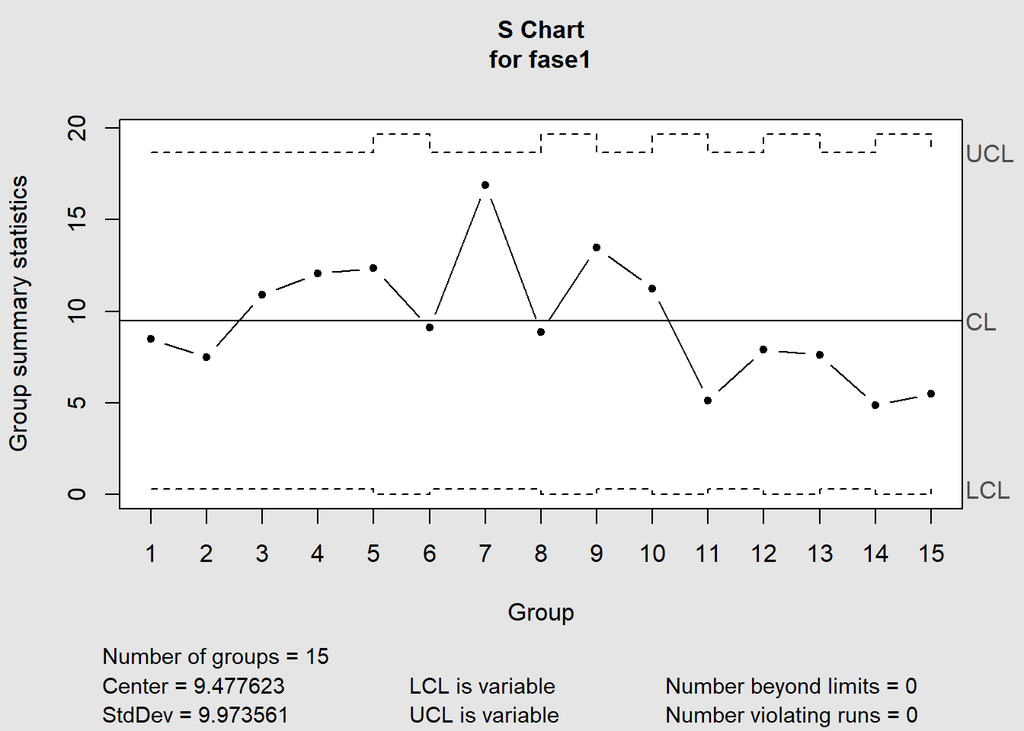

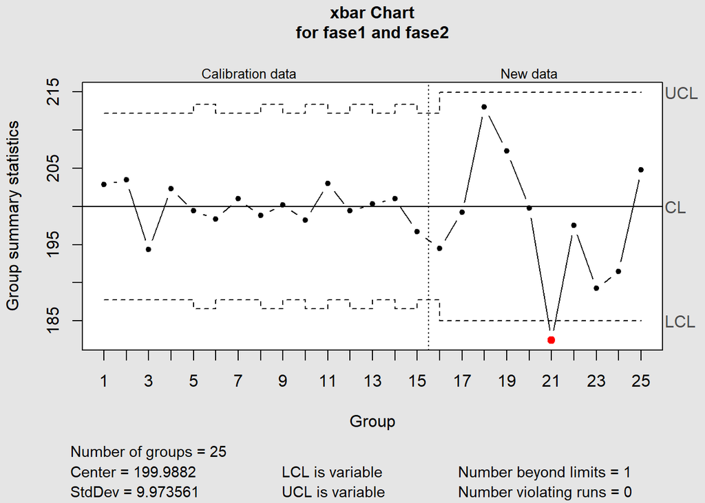

```
## **Conclusão:**
```

```
## Os gráficos x-barra e S foram construídos com base nas 15 amostras da Fase 1, com diferentes tamanhos amostrais (5 ou 6).
```

```
## A Fase 2, com amostras de tamanho 4, foi adicionada para monitoramento.
```

```
## Se houver pontos fora dos limites ou padrões suspeitos, isso indica descontrole estatístico.
```